# PEC1_Analisis Estadistico

Nathalia Fernandez Rodrigues

16/12/2021

# 1 Sistemas Bike Sharing

El conjunto de datos bikes.csv contiene informacion sobre el alquiler y devolucion automatizado de bicicletas en dferentes ciudades. Se debe predecir el nivel diario de alquiler de bicicletas a partir de variables ambientales y estacionales.

# 2 Carga de datos

Lectura del fichero de datos **“bikes.csv”** se guardan los datos en un objeto con identificador denominado **bikes**

```r
setwd("C:/Users/natha/OneDrive/Desktop/MASTER - DS/2. TECNICAS DE ANALISIS ESTADISTICO/Data")
bikes<- read.csv("bikes.csv", header=TRUE, sep=",", dec=".", fileEncoding = "UTF-8")
```

## 2.1 *Descripción de la estructura los datos*

Se muestra una descripción de la estructura de datos para conocer número de filas, número de columnas, nombre de las columnas y tipo de datos:

```r
str(bikes)
```

```
## 'data.frame':    731 obs. of  16 variables:
##  $ instant   : int  1 2 3 4 5 6 7 8 9 10 ...
##  $ dteday    : chr  "2011-01-01" "2011-01-02" "2011-01-03" "2011-01-04" ...
##  $ season    : int  1 1 1 1 1 1 1 1 1 1 ...
##  $ yr        : int  0 0 0 0 0 0 0 0 0 0 ...
##  $ mnth      : int  1 1 1 1 1 1 1 1 1 1 ...
##  $ holiday   : int  0 0 0 0 0 0 0 0 0 0 ...
##  $ weekday   : int  6 0 1 2 3 4 5 6 0 1 ...
##  $ workingday: int  0 0 1 1 1 1 1 0 0 1 ...
##  $ weathersit: int  2 2 1 1 1 1 2 2 1 1 ...
##  $ temp      : num  0.344 0.363 0.196 0.2 0.227 ...
##  $ atemp     : num  0.364 0.354 0.189 0.212 0.229 ...
##  $ hum       : num  0.806 0.696 0.437 0.59 0.437 ...
##  $ windspeed : num  0.16 0.249 0.248 0.16 0.187 ...
##  $ casual    : int  331 131 120 108 82 88 148 68 54 41 ...
##  $ registered: int  654 670 1229 1454 1518 1518 1362 891 768 1280 ...
##  $ cnt       : int  985 801 1349 1562 1600 1606 1510 959 822 1321 ...
```

Se muestra un resumen para conocer minimo, maximo, quantiles media y mediana de los datos.

```r
summary(bikes)
```

```
##     instant         dteday              season            yr
##  Min.   :  1.0   Length:731         Min.   :1.000   Min.   :0.0000
##  1st Qu.:183.5   Class :character   1st Qu.:2.000   1st Qu.:0.0000
##  Median :366.0   Mode  :character   Median :3.000   Median :1.0000
##  Mean   :366.0                      Mean   :2.497   Mean   :0.5007
##  3rd Qu.:548.5                      3rd Qu.:3.000   3rd Qu.:1.0000
##  Max.   :731.0                      Max.   :4.000   Max.   :1.0000
##       mnth          holiday           weekday        workingday
##  Min.   : 1.00   Min.   :0.00000   Min.   :0.000   Min.   :0.000
##  1st Qu.: 4.00   1st Qu.:0.00000   1st Qu.:1.000   1st Qu.:0.000
##  Median : 7.00   Median :0.00000   Median :3.000   Median :1.000
##  Mean   : 6.52   Mean   :0.02873   Mean   :2.997   Mean   :0.684
##  3rd Qu.:10.00   3rd Qu.:0.00000   3rd Qu.:5.000   3rd Qu.:1.000
##  Max.   :12.00   Max.   :1.00000   Max.   :6.000   Max.   :1.000
##    weathersit         temp             atemp              hum
##  Min.   :1.000   Min.   :0.05913   Min.   :0.07907   Min.   :0.0000
##  1st Qu.:1.000   1st Qu.:0.33708   1st Qu.:0.33784   1st Qu.:0.5200
##  Median :1.000   Median :0.49833   Median :0.48673   Median :0.6267
##  Mean   :1.395   Mean   :0.49538   Mean   :0.47435   Mean   :0.6279
##  3rd Qu.:2.000   3rd Qu.:0.65542   3rd Qu.:0.60860   3rd Qu.:0.7302
##  Max.   :3.000   Max.   :0.86167   Max.   :0.84090   Max.   :0.9725
##    windspeed           casual         registered        cnt
##  Min.   :0.02239   Min.   :   2.0   Min.   :  20   Min.   :  22
##  1st Qu.:0.13495   1st Qu.: 315.5   1st Qu.:2497   1st Qu.:3152
##  Median :0.18097   Median : 713.0   Median :3662   Median :4548
##  Mean   :0.19049   Mean   : 848.2   Mean   :3656   Mean   :4504
##  3rd Qu.:0.23321   3rd Qu.:1096.0   3rd Qu.:4776   3rd Qu.:5956
##  Max.   :0.50746   Max.   :3410.0   Max.   :6946   Max.   :8714
```

Se comprueba la existencia de valores NA’s en el DataFrame.

```r
bikes %>%
  summarise_all(.funs = ~ sum(is.na(.)))
```

```
##   instant dteday season yr mnth holiday weekday workingday weathersit temp
## 1       0      0      0  0    0       0       0          0          0    0
##   atemp hum windspeed casual registered cnt
## 1     0   0         0      0          0   0
```

**RESPUESTA**: No hay valores con NA’s.

# 3 Variables numéricas

**Analisis de las variables numéricas univariantemente**

De cada una de las variables se responden al final las siguientes preguntas:

- ¿Se distribuyen simétricamente?
- ¿Existe algún outlier?
- ¿Puedes dar un buen estimador de localización de las variables? Para cada una, si puedes, calcúlalo, si no argumenta por que.
- ¿Está la variable windspeed distribuida normalmente? Argumenta por que sí o no y utiliza alguno de los métodos estudiados.

## 3.1 *Variable CNT*

```r
alquiler <-bikes %>%
  summarise(
    media = mean(cnt),
    mediana = median(cnt),
    media_winsorizada = mean(cnt, trim = 0.1),
    desviacion_tipica = sd(cnt),
    varianza = var(cnt),
    IQR = IQR(cnt),
    maximo = max(cnt),
    minimo = min(cnt),
    Q1=quantile(cnt,0.25),
    Q3=quantile(cnt,0.75))

print(alquiler)
```

```
##      media mediana media_winsorizada desviacion_tipica varianza  IQR maximo
## 1 4504.349    4548           4517.19          1937.211  3752788 2804   8714
##   minimo   Q1   Q3
## 1     22 3152 5956
```

**Estimador de localización de la variable cnt**

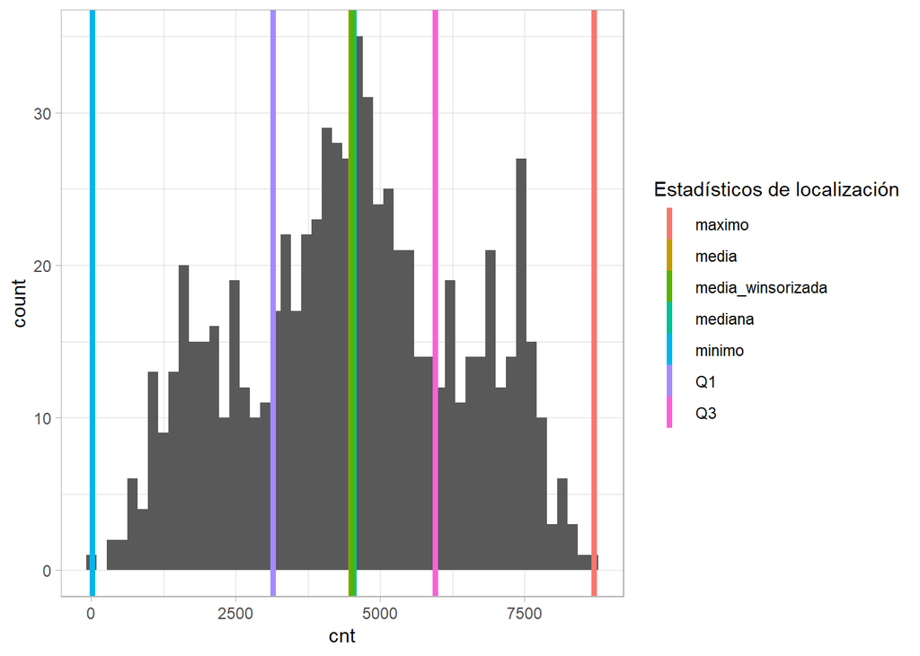

**Grafico Combinado**

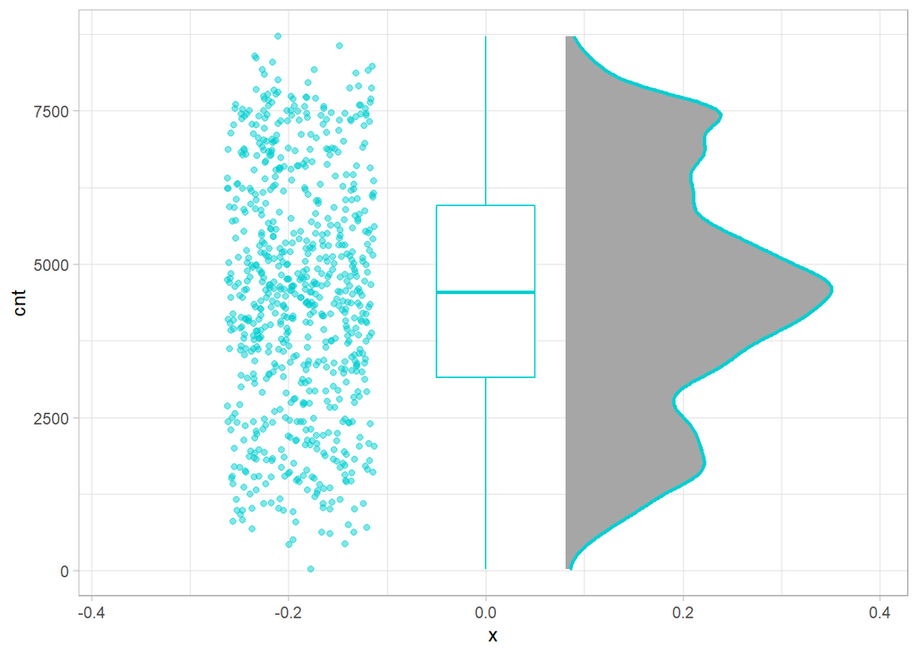